# Lab 6 - Email EDA and Dimensionality Reduction

Author: Kevin Paganini  
Date: 1/22/2023  
Description: -

```python
import pandas as pd
import numpy as np
import matplotlib.pyplot as plt
import os
import seaborn as sns
import sys
import glob as gb
import json

pd.set_option('display.max_rows', 250)


# makes plots nice
def make_pretty(ax, title='', x_label='', y_label='', img=False):
    ax.set_title(title, fontsize=20)
    ax.set_xlabel(x_label, fontsize=16)
    ax.set_ylabel(y_label, fontsize=16)
    ax.legend(loc='best', fontsize=16)
    if img:
        ax.axis('off')
    return ax


email_path = os.path.join('Data','email_json', 'email_json')
```

## Part 1 - Load the Data

```python
def load_json_files(directory):
    json_files = gb.glob(directory + '/*.json')

    json_dicts = []
    for file in json_files:
        with open(file) as json_file:
            json_dicts.append(json.load(json_file))
    return json_dicts



def dicts_to_dataframe(json_dicts):
    return pd.DataFrame(json_dicts)

df = dicts_to_dataframe(load_json_files(email_path))
```

```python
df.head()
```

|  | category | to_address | from_address | subject | body |
| --- | --- | --- | --- | --- | --- |
| 0 | spam | the00@speedy.uwaterloo.ca | "Tomas Jacobs" <RickyAmes@aol.com> | Generic Cialis, branded quality@ | \n\n\n\n\n\n\nDo you feel the pressure to perf... |
| 1 | ham | debian-mirrors@lists.debian.org | Yan Morin <yan.morin@savoirfairelinux.com> | Typo in /debian/README | Hi, i've just updated from the gulus and I che... |
| 2 | spam | <the00@plg.uwaterloo.ca> | "Sheila Crenshaw" <7stocknews@tractionmarketin... | authentic viagra | authentic viagra\n\nMega authenticV I A G R A... |
| 3 | spam | opt4@speedy.uwaterloo.ca | "Stormy Dempsey" <vqucsmdfgvsg@ruraltek.com> | Nice talking with ya | \nHey Billy, \n\nit was really fun going out t... |
| 4 | spam | ktwarwic@speedy.uwaterloo.ca | "Christi T. Jernigan" <dcube@totalink.net> | or trembling; stomach cramps; trouble in sleep... | \n\n\n\n\n\n\nsystem" of the home. It will ha... |

```python
df.shape
```

```
(63542, 5)
```

```python
df.info()
```

```
<class 'pandas.core.frame.DataFrame'>
RangeIndex: 63542 entries, 0 to 63541
Data columns (total 5 columns):
 #   Column        Non-Null Count  Dtype
---  ------        --------------  -----
 0   category      63542 non-null  object
 1   to_address    63141 non-null  object
 2   from_address  63542 non-null  object
 3   subject       63410 non-null  object
 4   body          63542 non-null  object
dtypes: object(5)
memory usage: 2.4+ MB
```

```python
df['category'] = df['category'].astype('category')
```

All columns besides the 'category' column are strings. The 'category' column is a categorical variable saying whether or not the emai is spam or ham.

## Part 2 - Extract Features

```python
from sklearn.feature_extraction.text import CountVectorizer

# the count vectorizer is a BOW representation
# each column is a unique token
# each row is one body of an email
# each value is how many times the word appeared in the email
# since we used binary, it is just if the word appears or not



cv = CountVectorizer(binary=True)
feat_mat = cv.fit_transform(df['body'].values)
print(f'Shape of the feature matrix: {feat_mat.shape}')
```

```
Shape of the feature matrix: (63542, 300984)
```

```python
print(f'Total elements: {feat_mat.shape[0] * feat_mat.shape[1]}')
```

```
Total elements: 19125125328
```

```python
print(f'Num non zero entries: {feat_mat.count_nonzero()}')
```

```
Num non zero entries: 6885706
```

```python
vocab = cv.vocabulary_

print(f'Number of entries in vocabulary_: {len(vocab.keys())}')

col_indice = list(vocab.keys())
work_index = col_indice.index('work')
love_index = col_indice.index('love')
different_index = col_indice.index('different')
w = 'work'
l = 'love'
d = 'different'
print(f'Index of work: {work_index}, value of work: {vocab[w]}')
print(f'Index of love: {love_index}, value of love: {vocab[l]}')
print(f'Index of different: {different_index}, value of different: {vocab[d]}')

# access feat mat col from the index found
print(f'Work index\n{feat_mat[:,work_index]}')
# print(f'Nonzero elements of work: {feat_mat[:,work_index].toarray().nonzero()[0]}')
print(f'Love index\n{feat_mat[:,love_index]}')
print(f'Different index\n{feat_mat[:,different_index]}')
```

```
Number of entries in vocabulary_: 300984
Index of work: 306, value of work: 289649
Index of love: 143, value of love: 183355
Index of different: 726, value of different: 125499
Work index
  (62113, 0)	1
  (62117, 0)	1
Love index
  (2448, 0)	1
Different index
  (37388, 0)	1
  (37447, 0)	1
```

## Part 3 - Dimensionality Reduction

Transforming features using TruncatedSVD - Similar to PCA but can be used with sparse matrices

```python
from sklearn.decomposition import TruncatedSVD


tsvd = TruncatedSVD(n_components=10, random_state=42)

transform_feat_mat = tsvd.fit_transform(feat_mat)
```

```python
tsvd.get_feature_names_out()
```

```
array(['truncatedsvd0', 'truncatedsvd1', 'truncatedsvd2', 'truncatedsvd3',
       'truncatedsvd4', 'truncatedsvd5', 'truncatedsvd6', 'truncatedsvd7',
       'truncatedsvd8', 'truncatedsvd9'], dtype=object)
```

```python
transform_feat_mat.shape
```

```
(63542, 10)
```

```
No artists with labels found to put in legend.  Note that artists whose label start with an underscore are ignored when legend() is called with no argument.
```

```
Explained Variance ratio: [0.05291813 0.02548106 0.01589105 0.0120487  0.01252029 0.00997985
 0.00969489 0.00913387 0.00739935 0.0072696 ]
```

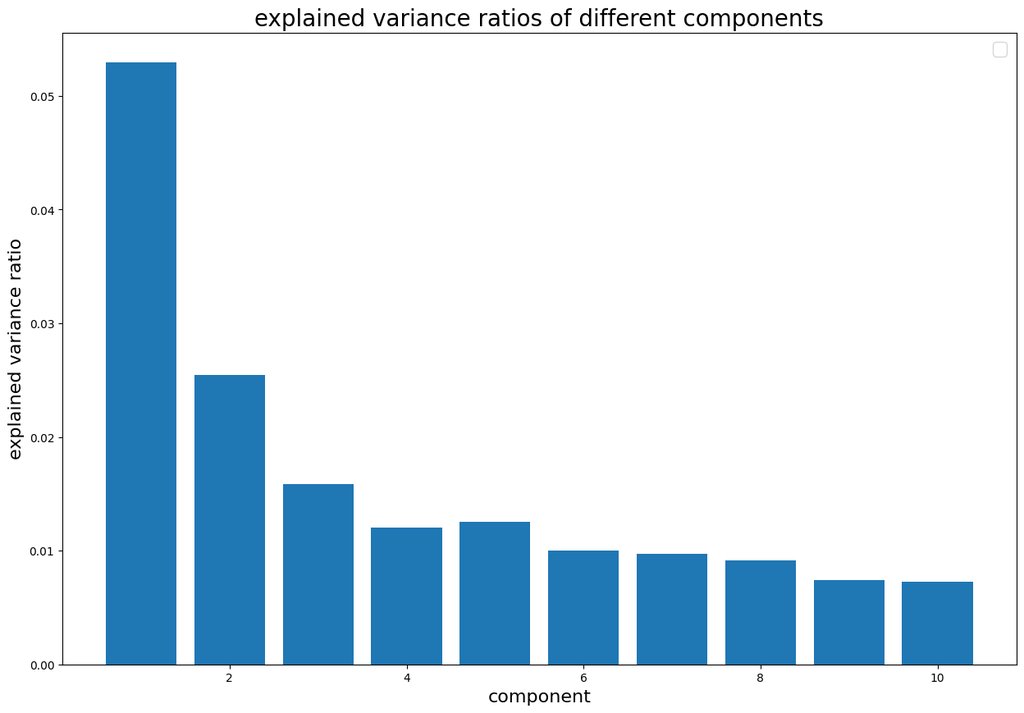

```python
print(f'Explained Variance ratio: {tsvd.explained_variance_ratio_}')

fig, ax = plt.subplots(figsize=(15, 10))

xx = np.arange(1, 11)


ax.bar(xx, tsvd.explained_variance_ratio_)
make_pretty(ax, 'explained variance ratios of different components', 'component', 'explained variance ratio')
```

The first and second components have the highest explained variance ratio.

## Part 4 - Visualization

```
No artists with labels found to put in legend.  Note that artists whose label start with an underscore are ignored when legend() is called with no argument.
```

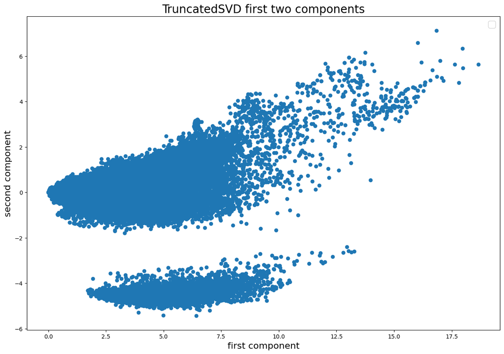

```python
fig, ax = plt.subplots(figsize=(15, 10))

ax.scatter(transform_feat_mat[:,0], transform_feat_mat[:,1])
make_pretty(ax, 'TruncatedSVD first two components', 'first component', 'second component')
```

```python
df['comp1'] = transform_feat_mat[:,0]
df['comp2'] = transform_feat_mat[:,1]

def change(x):
    if x == 'spam':
        return 0
    else:
        return 1

df['category'] = df['category'].map(change)
```

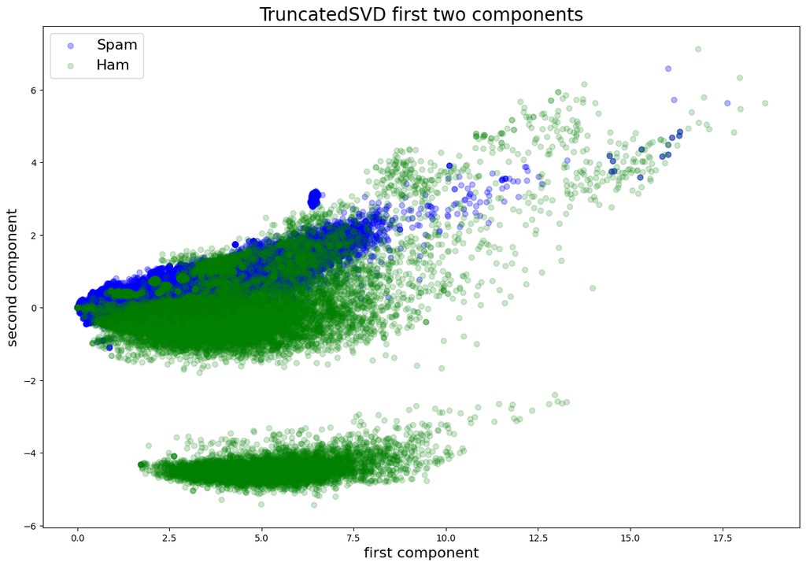

```python
fig, ax = plt.subplots(figsize=(15, 10))

plot_0 = df[df['category'] == 0]
plot_1 = df[df['category'] == 1]

ax.scatter(plot_0['comp1'], plot_0['comp2'], c='blue', label='Spam', alpha=0.3)
ax.scatter(plot_1['comp1'], plot_1['comp2'], c='green', label='Ham', alpha=0.2)


make_pretty(ax, 'TruncatedSVD first two components', 'first component', 'second component')
```

Alpha of 0.2 was used on the green samples to display the blue behind it nicely. There is a big overlap between the two categories in the top cluster. However there is also a nice seperation of the bottom cluster, which is all ham.

## Reflection Questions

1. Use a text editor to look at one of the JSON files. Describe the JSON file. What are

the keys and values of the JSON document? What do you think they correspond to?

- The keys are column names while the values are the actual data. One json file is one row.
- category: is the e-mail spam or real? (spam or ham)
- to_address: the e-mail address the e-mail went to
- from_address: the e-mail address the e-mail came from
- subject: the subject line of the e-mail
- body: the contents of the e-mail
2. Assume that 32-bit (4-byte) floating point values are used to store the counts. Calculate the memory usage of a dense matrix with those dimensions. (which dimensions)
- Shape of the feature matrix: (63542, 300984). If the feature matrix were dense that would mean we had 63542 * 300984 elements. Each one would be 4 bytes, therefore the calculation is: $63542 * 300984 * 4 = 7.65005 * 10^{10}$. This is equivalent to 76.5 gigabytes. Too much for RAM.
3. The vectorizer returns a sparse matrix in compressed row format (CSR). Assume that the sparse matrix uses one 32-bit (4-byte) floating point number and one 32-bit (4-byte) integer for each nonzero entry and one 32-bit (4-byte) integer for each row. Calculate the memory usage for the sparse matrix.
- Number of Nonzero entries: 6885706
- Store one entry: 4 bytes for number + 4 bytes for column + 4 bytes for index = 12 bytes
- 6885706 * 12 = 0.082628472 gigabytes.
- This is a lot of space saving, we would have stored a lot of zeros.
4. Calculate the sparsity ratio (100 * number of nonzero entries divided by maximum possible entries).
- 100 * (6885706 / 63542 * 300984) = 0.036%
- Thats a big space savings
5. Based on your analysis, do you think that the sparse matrix is better suited for this situation? If so, why?
- The sparse matrix is better suited in this situation, sine we are using a CountVectorizer we will be producing a lot of zero values. In fact, more than 99% of the values in the sparse matrix are zero. Storing these makes little sense and using a CSR format can eliminate the wasteful storage of these zero values. The access time of the CSR matrix is slightly slower, however the memory savings we get are well worth it.
6. What do you notice when looking at the first scatter plot? Why do you think this pattern appears?
- In the first scatter plot one can see two distinct groupings. One of the clusters is a lot bigger than the other one.
- This is most likely due to the fact that we are plotting the first two components of the TruncatedSVD. We get the seperation of clusters from component 2. Since we plotted component 2 on the y axis, we see the clusters at different y levels.
7. In the second plot, how you describe the relationship between the pattern you

observe and the ham and spam messages?

- I expected the bottom cluster to be spam and the top cluster to be ham, but instead the top cluster is split into two with spam and ham samples within. The spam samples are nicely clustered in the top left of the top cluster, however there are ham samples that overlap with the spam cluster. We do not have good seperation between spam and ham.